# R Markdown Presentation

**|| 2211 Vishal || 2213 Tushar || 2224 Mayur || 2242 Mithilesh ||**

*11-Dec-2022(Sunday)*

# Introduction

R Markdown provides a unified authoring framework for data science, combining your code, its results, and your prose commentary. R Markdown documents are fully reproducible and support dozens of output formats, like PDFs, Word files, slideshows, and more.

### R Markdown files are designed to be used in three ways:

- For communicating to decision makers, who want to focus on the conclusions, not the code behind the analysis.
- For collaborating with other data scientists (including future you!), who are interested in both your conclusions, and how you reached them (i.e., the code).
- As an environment in which to do data science, as a modern day lab notebook where you can capture not only what you did, but also what you were thinking.
- *R Markdown Cheat Sheet:* available in the *RStudio IDE* under **Help → Cheatsheets → R Markdown Cheat Sheet**
- *R Markdown Reference Guide:* available in the RStudio IDE under **Help → Cheatsheets → R Markdown Reference Guide**

# # To colour document title and other things mentioned in the title we use the following commands i.e.

title: `<span style="color:purple">` R Markdown Presentation

author: `<span style="color:blue">`**|| 2211 Vishal || 2213 Tushar || 2224 Mayur || 2242 Mithilesh ||**

date: `<span style="color:red">` *11-Dec-2022(Sunday)*

output: slidy_presentation

fig_width: 3 (to adjust graph width)

fig_height: 4 (to adjust graph heigth)

# ## R Markdown document

[figure not shown]

markdown document

# Documents

- pdf_document makes a PDF with LaTeX (an open source docu‐ ment layout system), which you’ll need to install. RStudio will prompt you if you don’t already have it.
- word_document for Microsoft Word documents (.docx).
- odt_document for OpenDocument Text documents (.odt).
- rtf_document for Rich Text Format (.rtf) documents.
- md_document for a Markdown document. This isn’t typically useful by itself, but you might use it if, for example, your corpo‐ rate CMS or lab wiki uses Markdown.
- github_document is a tailored version of md_document designed for sharing on GitHub.

# R Markdown Presentation

[figure not shown]

markdown presentation

# Presentation

- ioslides_presentation :- HTML presentation with ioslides.
- slidy_presentation :- HTML presentation with W3C Slidy.
- beamer_presentation :- PDF presentation with LaTeX Beamer.
- Two other popular formats are provided by packages:
- revealjs::revealjs_presentation

HTML presentation with reveal.js. Requires the revealjs pack‐ age.

- rmdshower :- Provides a wrapper around the shower presentation engine
- rmdshower

Provides a wrapper around the shower presentation engine.

# R Markdown shiny

[figure not shown]

markdown shiny

# Shiny

To call Shiny code from an R Markdown document, add runtime: shiny to the header:

title: “Shiny Web App” output: html_document runtime: shiny

Then you can use the “input” functions to add interactive compo‐ nents to the document:input code$\rightarrow$

- > library(shiny)
- > textInput(“name”, “What is your name?”)
- > numericInput(“age”, “How old are you?”, NA, min = 0, max = 150)

You can then refer to the values with *input$name and input$age*, and the code that uses them will be automatically rerun whenever they change. *Output* $\rightarrow$

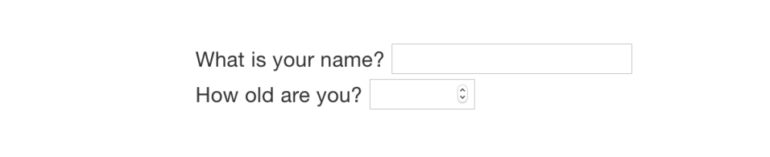

markdown

# Templets In R Markdown

[figure not shown]

markdown templets

# Dashboards

- Each level 1 header (#) begins a new page in the dashboard.
- Each level 2 header (##) begins a new column.
- Each level 3 header (###) begins a new row.

output:

flexdashboard::flex_dashboard:

orientation: columns

vertical_layout: fill

runtime: shiny `---`

```r
library(flexdashboard)
library(dplyr)
```

```r
library(shiny)
library(plotly)
attach(iris)
```

# Column `{.sidebar data-width=200}`

### Chart B

```r
data=iris
cat_var=unique(data["Species"])
cont_var=colnames(data)[-5]
```

```r
selectInput("sel_species","select Species of interest",choices=cat_var)
```

select Species of interest

```r
selectInput("sel_x","select independent var",choices=cont_var)
```

select independent var

```r
selectInput("sel_y","selet select dependent var",choices=cont_var)
```

selet select dependent var

# `Column {data-width=400}`

### Chart C

```r
renderPlotly({
  plot_ly(data,
          x= ~data[[input$sel_x]],
         y= ~data[[input$sel_y]],
         type="box")
})
```

[interactive chart not shown]

- For example, you can produce this dashboard:

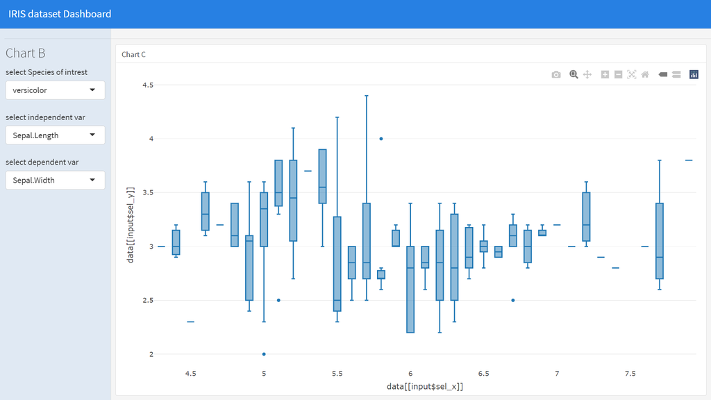

markdown flexboard

### Text Formatting with Markdown

#### Text formatting

To italic or bold or code or superscript the given text we use

- `_italic_` or `*italic*` :- text under stars or underscore as “*italic*”
- `**bold**` or `__bold__` :- text under double stars or double underscore as “**Bold**”
- `code` :- to write text in a code format or font as “`code`”
- `superscript^2^` and `subscript~2~` :- to write text as “superscript<sup>2</sup>” and “subscript<sub>2</sub>”

### Headings

#### Headings

`# 1st Level Header` As

#1st Level Header

`## 2nd Level Header` As

## 2nd Level Header

`### 3rd Level Header` As

### 3rd Level Header

# Lists

`* Bulleted list item 1`

- Bulleted list item 1

`* Item 2`

- Item 2

`* Item 2a`

- Item 2a

`1. Numbered list item 1`

1. Numbered list item 1

`1. Item 2. The numbers are incremented automatically in the output.`

1. Item 2. The numbers are incremented automatically in the output. ———————————————————-

# Links and images

- To add link to our document

Example

`<http://nmu.ac.in>`

http://nmu.ac.in

OR

`[KBCNMU Website](http://nmu.ac.in)`

click here : [KBCNMU Website](http://nmu.ac.in)

- To add image to our document

`![optional caption text](path/to/img.png)`

Example

`![R Markdown](C:\Users\Sarvadnya\Pictures\Screenshots\Screenshot (12).png) {width=50%}`

[figure not shown]

R Markdown